# Machine Learning UOC

Cristopher Valenzuela

13 de marzo de 2022

# Machine Learning aplicando algoritmos de Brett Lantz (2015).

Carga y limpieza de los datos

```r
datos<-read.csv("C:\\Users\\Cristopher\\Desktop\\certificados\\UOC\\Bioestadistica y Bioinformatica\\Libro Machine learning UOC\\Machine learning R UOC\\top_genes.csv")

rownames(datos) = datos$X
datos = datos[,-1]

datos$diagnostico = as.factor(datos$diagnostico)
datos[1:10,1:7]
```

```
##            diagnostico ILMN_1735360 ILMN_2075927 ILMN_3299478 ILMN_2210934
## GSM1033105           1  -1.12219307   0.80822327  -1.46840346  -0.69460155
## GSM1033106           1  -0.11504635   0.80822327  -1.29366251   0.57751411
## GSM1033107           1   0.02193304   0.38877404   1.18460015   0.19815997
## GSM1033108           1  -0.38507324   0.57960640   0.01387744   0.51554737
## GSM1033109           0  -0.34248662   0.80497915  -1.54717813  -0.23852907
## GSM1033110           0  -0.08795432  -0.08232094  -1.20381682   0.05250994
## GSM1033111           1   0.01813623  -0.16481130  -1.55571933  -0.07377526
## GSM1033112           0  -1.21380762   1.67062489  -0.75122399  -0.14563415
## GSM1033113           1   0.93607336   0.07979375  -0.35074004  -1.16401824
## GSM1033114           0  -0.44923689   1.41956576  -1.04193219   1.27534220
##            ILMN_3280402 ILMN_1813573
## GSM1033105  0.008956249    0.2203982
## GSM1033106 -0.040982526   -0.3163514
## GSM1033107 -0.725678157   -0.3232627
## GSM1033108 -0.205165212    1.2774123
## GSM1033109  0.185173974    0.6886360
## GSM1033110 -0.070210143    0.3649350
## GSM1033111 -0.257343985    0.1653713
## GSM1033112  0.143103448    1.3863804
## GSM1033113 -1.194767115    0.4694753
## GSM1033114 -0.054086084    1.4152209
```

# k-NN algorithm

```r
table(datos$diagnostico)
```

```
##
##  0  1
## 56 91
```

```r
round(prop.table(table(datos$diagnostico)) * 100, digits = 1)
```

```
##
##    0    1
## 38.1 61.9
```

Creamos los datos de entrenamiento y test

```r
 knn_train <- datos[1:100, ]
 knn_test <- datos[101:147, ]

 #creamos tambien las etiquetas
 knn_train_labels <- datos[1:100, 1]
 knn_test_labels <- datos[101:147, 1]
```

Entrenar el modelo con los datos

```r
library(class)

knn_test_pred <- knn(train = knn_train, test = knn_test,
cl = knn_train_labels, k = 5)

knn_test_pred
```

```
##  [1] 1 1 0 0 1 1 1 1 1 1 1 0 1 1 1 1 1 1 1 1 1 1 1 1 1 1 1 0 1 1 1 1 1 1 0 1 1 1
## [39] 0 0 1 1 1 1 1 1 1
## Levels: 0 1
```

Evaluacion del modelo

```r
library(gmodels)
CrossTable(x = knn_test_labels, y = knn_test_pred,prop.chisq=FALSE)
```

```
##
##
##    Cell Contents
## |-------------------------|
## |                       N |
## |           N / Row Total |
## |           N / Col Total |
## |         N / Table Total |
## |-------------------------|
##
##
## Total Observations in Table:  47
##
##
##                 | knn_test_pred
## knn_test_labels |         0 |         1 | Row Total |
## ----------------|-----------|-----------|-----------|
##               0 |         7 |         3 |        10 |
##                 |     0.700 |     0.300 |     0.213 |
##                 |     1.000 |     0.075 |           |
##                 |     0.149 |     0.064 |           |
## ----------------|-----------|-----------|-----------|
##               1 |         0 |        37 |        37 |
##                 |     0.000 |     1.000 |     0.787 |
##                 |     0.000 |     0.925 |           |
##                 |     0.000 |     0.787 |           |
## ----------------|-----------|-----------|-----------|
##    Column Total |         7 |        40 |        47 |
##                 |     0.149 |     0.851 |           |
## ----------------|-----------|-----------|-----------|
##
##
```

La precisión fue de 44 casos clasificados correctamente sobre 47, una precisión del 93.61702%.

# Classification Using Naive Bayes

```r
library(e1071)

 nb_train <- datos[1:100, ]
 nb_test <- datos[101:147, ]

 #creamos tambien las etiquetas
 nb_train_labels <- datos[1:100, 1]
 nb_test_labels <- datos[101:147, 1]

#creacion del modelo
nb_classifier <- naiveBayes(nb_train, nb_train_labels)

nb_classifier
```

```
##
## Naive Bayes Classifier for Discrete Predictors
##
## Call:
## naiveBayes.default(x = nb_train, y = nb_train_labels)
##
## A-priori probabilities:
## nb_train_labels
##    0    1
## 0.46 0.54
##
## Conditional probabilities:
##                diagnostico
## nb_train_labels 0 1
##               0 1 0
##               1 0 1
##
##                ILMN_1735360
## nb_train_labels       [,1]      [,2]
##               0 -0.6146445 0.9611105
##               1  0.2120489 0.8992136
##
##                ILMN_2075927
## nb_train_labels        [,1]      [,2]
##               0 -0.41350336 1.0372803
##               1  0.09124562 0.9040495
##
##                ILMN_3299478
## nb_train_labels        [,1]      [,2]
##               0 -0.61844749 1.0328947
##               1  0.08632433 0.8599286
##
##                ILMN_2210934
## nb_train_labels       [,1]      [,2]
##               0 -0.4464008 0.8706161
##               1  0.3874406 0.8202356
##
##                ILMN_3280402
## nb_train_labels       [,1]      [,2]
##               0  0.6890272 0.9886962
##               1 -0.2930292 0.8263120
##
##                ILMN_1813573
## nb_train_labels       [,1]      [,2]
##               0 -0.6875917 1.0510369
##               1  0.1214001 0.7936871
```

Evaluación del modelo

```r
nb_test_pred <- predict(nb_classifier, nb_test)
nb_test_pred
```

```
##  [1] 1 1 0 0 1 0 1 1 1 1 1 0 1 1 1 1 0 1 1 1 1 1 1 1 1 1 1 0 1 1 1 1 1 1 0 1 1 1
## [39] 0 0 1 1 1 1 1 1 0
## Levels: 0 1
```

Evaluacion del modelo

```r
 library(gmodels)
CrossTable(nb_test_pred, nb_test_labels,
prop.chisq = FALSE, prop.t = FALSE,
dnn = c('predicted', 'actual'))
```

```
##
##
##    Cell Contents
## |-------------------------|
## |                       N |
## |           N / Row Total |
## |           N / Col Total |
## |-------------------------|
##
##
## Total Observations in Table:  47
##
##
##              | actual
##    predicted |         0 |         1 | Row Total |
## -------------|-----------|-----------|-----------|
##            0 |        10 |         0 |        10 |
##              |     1.000 |     0.000 |     0.213 |
##              |     1.000 |     0.000 |           |
## -------------|-----------|-----------|-----------|
##            1 |         0 |        37 |        37 |
##              |     0.000 |     1.000 |     0.787 |
##              |     0.000 |     1.000 |           |
## -------------|-----------|-----------|-----------|
## Column Total |        10 |        37 |        47 |
##              |     0.213 |     0.787 |           |
## -------------|-----------|-----------|-----------|
##
##
```

Logro predecir el 47 de 47, una precision del 100%.

# Tree

```r
#tomaremos 100 numeros aleatorios del 1 al 147
set.seed(2022)
tree_sample <- sample(147, 100)

#creamos el entrenamiento y el test
 tree_train <- datos[tree_sample, ]
 tree_test <- datos[-tree_sample, ]

#calculamos los porcentaje de cada variable
prop.table(table(tree_train$diagnostico))
```

```
##
##    0    1
## 0.41 0.59
```

```r
prop.table(table(tree_test$diagnostico))
```

```
##
##         0         1
## 0.3191489 0.6808511
```

Entrenar el modelo

```r
library(C50)

#Primero excluimos la variable dependiente y despues la agregamos en el modelo.
tree_model <- C5.0(tree_train[-1], tree_train$diagnostico)
tree_model
```

```
##
## Call:
## C5.0.default(x = tree_train[-1], y = tree_train$diagnostico)
##
## Classification Tree
## Number of samples: 100
## Number of predictors: 6
##
## Tree size: 4
##
## Non-standard options: attempt to group attributes
```

```r
summary(tree_model)
```

```
##
## Call:
## C5.0.default(x = tree_train[-1], y = tree_train$diagnostico)
##
##
## C5.0 [Release 2.07 GPL Edition]      Wed Mar 16 03:24:23 2022
## -------------------------------
##
## Class specified by attribute `outcome'
##
## Read 100 cases (7 attributes) from undefined.data
##
## Decision tree:
##
## ILMN_3280402 > 0.5178679: 0 (19/2)
## ILMN_3280402 <= 0.5178679:
## :...ILMN_1735360 > 0.1032051: 1 (42/5)
##     ILMN_1735360 <= 0.1032051:
##     :...ILMN_2075927 <= -0.6512226: 0 (8)
##         ILMN_2075927 > -0.6512226: 1 (31/11)
##
##
## Evaluation on training data (100 cases):
##
##      Decision Tree
##    ----------------
##    Size      Errors
##
##       4   18(18.0%)   <<
##
##
##     (a)   (b)    <-classified as
##    ----  ----
##      25    16    (a): class 0
##       2    57    (b): class 1
##
##
##  Attribute usage:
##
##  100.00% ILMN_3280402
##   81.00% ILMN_1735360
##   39.00% ILMN_2075927
##
##
## Time: 0.0 secs
```

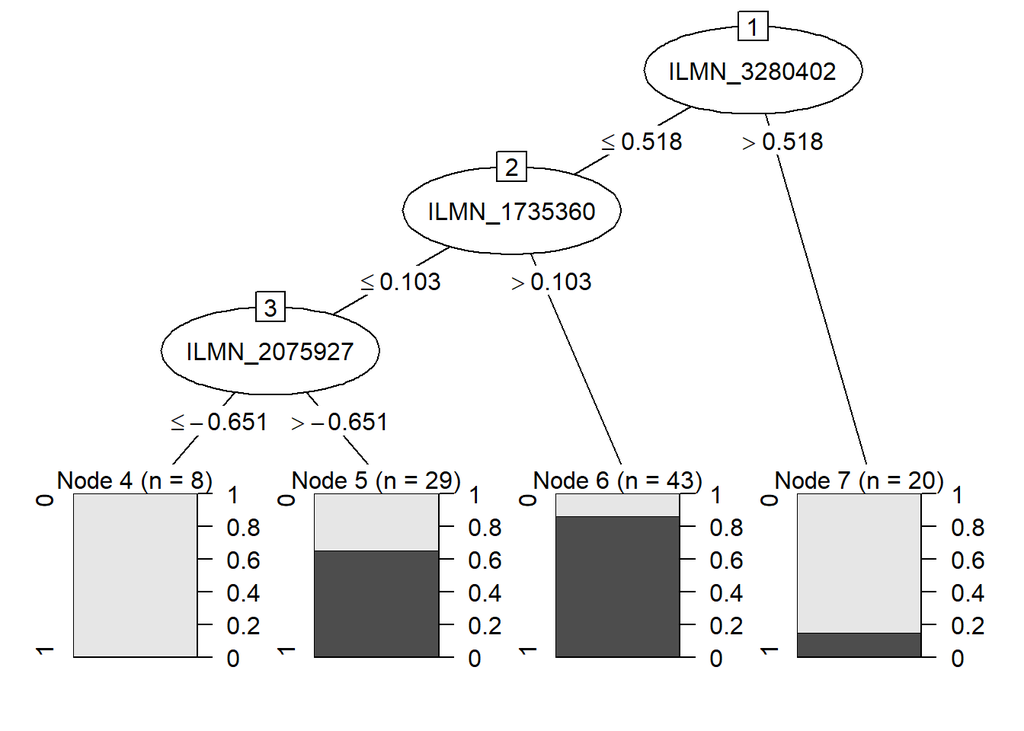

```r
plot(tree_model)
```

El modelo fallo 18 de 100, el modelo tiene una precision del 82%.

Evaluacion del rendimiento del modelo

```r
tree_pred <- predict(tree_model, tree_test)
tree_pred
```

```
##  [1] 1 1 1 1 1 1 0 0 0 0 0 0 0 0 0 0 0 1 1 1 1 1 1 1 1 1 1 1 1 1 1 1 1 1 1 1 1 1
## [39] 1 1 1 1 0 1 1 0 1
## Levels: 0 1
```

```r
 library(gmodels)
 CrossTable(tree_test$diagnostico, tree_pred,
prop.chisq = FALSE, prop.c = FALSE, prop.r = FALSE,
dnn = c('actual default', 'predicted default'))
```

```
##
##
##    Cell Contents
## |-------------------------|
## |                       N |
## |         N / Table Total |
## |-------------------------|
##
##
## Total Observations in Table:  47
##
##
##                | predicted default
## actual default |         0 |         1 | Row Total |
## ---------------|-----------|-----------|-----------|
##              0 |         9 |         6 |        15 |
##                |     0.191 |     0.128 |           |
## ---------------|-----------|-----------|-----------|
##              1 |         4 |        28 |        32 |
##                |     0.085 |     0.596 |           |
## ---------------|-----------|-----------|-----------|
##   Column Total |        13 |        34 |        47 |
## ---------------|-----------|-----------|-----------|
##
##
```

En este caso la tuvo aciertos de 37 de 47, una precision del 78.7234%.

Realizamos nuevamente el modelo pero para disminuir el error haremos una modificacion agregando "adaptive boosting".

```r
#Utilizamos por defecto trials = 10
tree_boost10 <- C5.0(tree_train[-1], tree_train$diagnostico,
trials = 10)

tree_boost10
```

```
##
## Call:
## C5.0.default(x = tree_train[-1], y = tree_train$diagnostico, trials = 10)
##
## Classification Tree
## Number of samples: 100
## Number of predictors: 6
##
## Number of boosting iterations: 10 requested;  6 used due to early stopping
## Average tree size: 3.3
##
## Non-standard options: attempt to group attributes
```

```r
summary(tree_boost10)
```

```
##
## Call:
## C5.0.default(x = tree_train[-1], y = tree_train$diagnostico, trials = 10)
##
##
## C5.0 [Release 2.07 GPL Edition]      Wed Mar 16 03:24:24 2022
## -------------------------------
##
## Class specified by attribute `outcome'
##
## Read 100 cases (7 attributes) from undefined.data
##
## -----  Trial 0:  -----
##
## Decision tree:
##
## ILMN_3280402 > 0.5178679: 0 (19/2)
## ILMN_3280402 <= 0.5178679:
## :...ILMN_1735360 > 0.1032051: 1 (42/5)
##     ILMN_1735360 <= 0.1032051:
##     :...ILMN_2075927 <= -0.6512226: 0 (8)
##         ILMN_2075927 > -0.6512226: 1 (31/11)
##
## -----  Trial 1:  -----
##
## Decision tree:
##
## ILMN_3299478 <= -0.751224: 0 (26.9/4.8)
## ILMN_3299478 > -0.751224:
## :...ILMN_2075927 > -0.2976235: 1 (36.5/5.7)
##     ILMN_2075927 <= -0.2976235:
##     :...ILMN_2210934 <= 0.7978899: 0 (30.9/8.3)
##         ILMN_2210934 > 0.7978899: 1 (5.6)
##
## -----  Trial 2:  -----
##
## Decision tree:
##
## ILMN_2210934 <= -1.644855: 0 (8.2)
## ILMN_2210934 > -1.644855:
```

[output cut: 55 more lines]

```
##      31    10    (a): class 0
##       2    57    (b): class 1
##
##
##  Attribute usage:
##
##  100.00% ILMN_3299478
##  100.00% ILMN_2210934
##  100.00% ILMN_3280402
##   93.00% ILMN_1735360
##   92.00% ILMN_1813573
##   88.00% ILMN_2075927
##
##
## Time: 0.0 secs
```

En este caso, se obtuvo 88 aciertos, que corresponde al 88%, implica un aumento en la precision del modelo.

Se analiza si ocurre una mejor en los datos de prueba

```r
 tree_boost_pred10 <- predict(tree_boost10, tree_test)
 CrossTable(tree_test$diagnostico, tree_boost_pred10,
prop.chisq = FALSE, prop.c = FALSE, prop.r = FALSE,
dnn = c('actual default', 'predicted default'))
```

```
##
##
##    Cell Contents
## |-------------------------|
## |                       N |
## |         N / Table Total |
## |-------------------------|
##
##
## Total Observations in Table:  47
##
##
##                | predicted default
## actual default |         0 |         1 | Row Total |
## ---------------|-----------|-----------|-----------|
##              0 |         9 |         6 |        15 |
##                |     0.191 |     0.128 |           |
## ---------------|-----------|-----------|-----------|
##              1 |         4 |        28 |        32 |
##                |     0.085 |     0.596 |           |
## ---------------|-----------|-----------|-----------|
##   Column Total |        13 |        34 |        47 |
## ---------------|-----------|-----------|-----------|
##
##
```

Se obtuvo aciertos de 37 sobre 47, en este caso no mejoro el modelo.

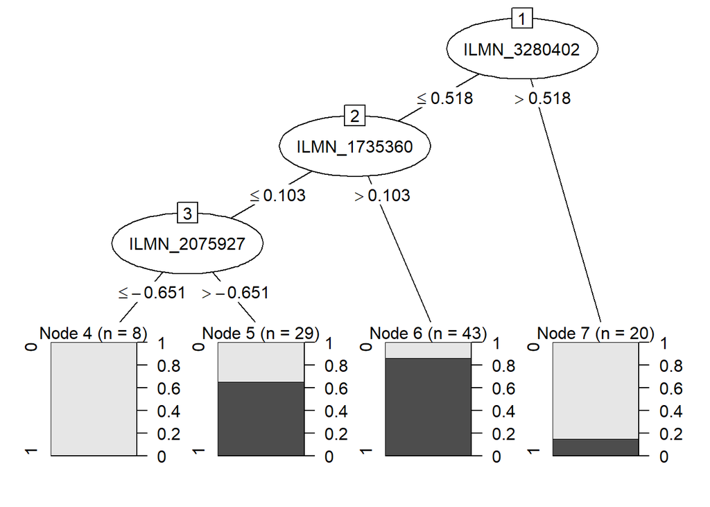

```r
plot(tree_boost10)
```

# Neural Networks for classification.

```r
#crear el train y el test

 nn_train <- datos[1:100, ]
 nn_test <- datos[101:147, ]
```

Entrenar el modelo mas simple con un nodo oculto

```r
library(neuralnet)

nn_model <- neuralnet(nn_train$diagnostico ~ .,
data = nn_train)

head(nn_model)
```

[output not shown]

[output cut: 283 more lines]

[output not shown]

```r
plot(nn_model)
```

[output not shown]

Evaluacion del modelo

```r
nn.model_results <- compute(nn_model, nn_test[2:7])

predicted_nn <- nn.model_results$net.result

cor(predicted_nn, as.numeric(nn_test$diagnostico))
```

```
##          [,1]
## [1,] -0.66367
## [2,]  0.66367
```

Mejorar el rendimiento del modelo

```r
#Incluir el parametro Hidden = 5

nn_model2 <- neuralnet(diagnostico ~ .,
data = nn_train, hidden = 5)

plot(nn_model2)
```

[output not shown]

# Support Vector Machines

Crear los datos de "train" y "test"

```r
 svm_train <- datos[1:100, ]
 svm_test <- datos[101:147, ]
```

Entrenar el modelo

```r
library(kernlab)

svm_classifier <- ksvm(diagnostico ~ ., data = svm_train,
kernel = "vanilladot")
svm_classifier
```

```
## Support Vector Machine object of class "ksvm"
##
## SV type: C-svc  (classification)
##  parameter : cost C = 1
##
## Linear (vanilla) kernel function.
##
## Number of Support Vectors : 55
##
## Objective Function Value : -52.1272
## Training error : 0.22
```

Mejorando el modelo

```r
svm_predictions <- predict(svm_classifier, svm_test)
svm_predictions
```

```
##  [1] 1 1 0 0 1 1 1 1 1 1 1 0 1 1 1 1 1 1 1 1 1 1 1 1 1 1 1 0 1 1 1 1 1 1 0 1 1 1
## [39] 0 0 0 1 1 1 0 1 1
## Levels: 0 1
```

```r
table(svm_predictions, svm_test$diagnostico)
```

```
##
## svm_predictions  0  1
##               0  7  2
##               1  3 35
```

Si queremos la evaluacion del modelo en true o false

```r
agreement <- svm_predictions == svm_test$diagnostico
table(agreement)
```

```
## agreement
## FALSE  TRUE
##     5    42
```

En terminos porcentuales

```r
prop.table(table(agreement))
```

```
## agreement
##    FALSE     TRUE
## 0.106383 0.893617
```

Tuvo una precision del 89%.

El modelo SVM anterior usaba la función kernel lineal simple. Mediante el uso de una función kernel más compleja, podemos mapear los datos en un espacio dimensional más alto y, potencialmente, obtener un mejor ajuste del modelo.

```r
#Lo haremos ahora con el Gaussian RBF kernel.

svm_classifier_rbf <- ksvm(diagnostico ~ ., data = svm_train,
kernel = "rbfdot")

#predicciones

svm_predictions_rbf <- predict(svm_classifier_rbf,svm_test)

#La precision

agreement_rbf <- svm_predictions_rbf == svm_test$diagnostico
table(agreement_rbf)
```

```
## agreement_rbf
## FALSE  TRUE
##     5    42
```

Una precision del 89%.

```r
prop.table(table(agreement_rbf))
```

```
## agreement_rbf
##    FALSE     TRUE
## 0.106383 0.893617
```

El modelo no mejoro se mantuvo en el 89%.

# Random Forest

```r
library(randomForest)

 set.seed(2022)
 rf <- randomForest(datos$diagnostico ~ ., data = datos)
rf
```

```
##
## Call:
##  randomForest(formula = datos$diagnostico ~ ., data = datos)
##                Type of random forest: classification
##                      Number of trees: 500
## No. of variables tried at each split: 2
##
##         OOB estimate of  error rate: 21.77%
## Confusion matrix:
##    0  1 class.error
## 0 39 17   0.3035714
## 1 15 76   0.1648352
```

Mejorar el modelo

```r
 library(caret)
 ctrl <- trainControl(method = "repeatedcv",
number = 10, repeats = 10)
```

configuraremos la cuadrícula de ajuste para el bosque aleatorio. El único parámetro de ajuste para este modelo es mtry, que define cuántas características se seleccionan aleatoriamente en cada división

```r
grid_rf <- expand.grid(.mtry = c(2, 4, 8, 16))

 set.seed(2022)
 m_rf <- train(diagnostico ~ ., data = datos, method = "rf",
metric = "Kappa", trControl = ctrl,
tuneGrid = grid_rf)
```

Lo compararemos con un árbol potenciado usando 10, 20, 30, y 40 interacciones

```r
 grid_c50 <- expand.grid(.model = "tree",.trials = c(10, 20, 30, 40),.winnow = "FALSE")

set.seed(2022)

 m_c50 <- train(diagnostico~ ., data = datos, method = "C5.0",metric = "Kappa", trControl = ctrl,tuneGrid = grid_c50)
```

Cuando finalmente se complete el árbol de decisiones de C5.0, podremos comparar los dos enfoques uno al lado del otro. Para el modelo de bosque aleatorio, los resultados son

```r
m_rf
```

```
## Random Forest
##
## 147 samples
##   6 predictor
##   2 classes: '0', '1'
##
## No pre-processing
## Resampling: Cross-Validated (10 fold, repeated 10 times)
## Summary of sample sizes: 133, 133, 131, 132, 133, 132, ...
## Resampling results across tuning parameters:
##
##   mtry  Accuracy   Kappa
##    2    0.7755417  0.5196497
##    4    0.7659226  0.5028626
##    8    0.7612857  0.4948991
##   16    0.7631964  0.4993954
##
## Kappa was used to select the optimal model using the largest value.
## The final value used for the model was mtry = 2.
```

El valor ideas es "2".

```r
m_c50
```

```
## C5.0
##
## 147 samples
##   6 predictor
##   2 classes: '0', '1'
##
## No pre-processing
## Resampling: Cross-Validated (10 fold, repeated 10 times)
## Summary of sample sizes: 133, 133, 131, 132, 133, 132, ...
## Resampling results across tuning parameters:
##
##   trials  Accuracy   Kappa
##   10      0.7390476  0.4371520
##   20      0.7404345  0.4402889
##   30      0.7404345  0.4402889
##   40      0.7404345  0.4402889
##
## Tuning parameter 'model' was held constant at a value of tree
## Tuning
##  parameter 'winnow' was held constant at a value of FALSE
## Kappa was used to select the optimal model using the largest value.
## The final values used for the model were trials = 20, model = tree and winnow
##  = FALSE.
```

El trials optimo seria el 20.